# 19

## Portfolio assignment 19

30 min: Create a cluster model on the penguins dataset.

- Use the pairplot() function on the penguins dataset. Do you visually notice any clusters? How many clusters do you think there are?
- Use the KMeans algorithm to create a cluster model. Apply this model to the dataset to create an extra column 'cluster' just like we did for the iris dataset above.  
  **Note**: Some machine learning algorithms can not handle missing values. You will either need to
  - replace missing values (with the mean or most popular value). For replacing missing values you can use .fillna(\<value>) https://pandas.pydata.org/docs/reference/api/pandas.Series.fillna.html
  - remove rows with missing data. You can remove rows with missing data with .dropna() https://pandas.pydata.org/pandas-docs/stable/reference/api/pandas.DataFrame.dropna.html
- Calculate the Silhouette Coefficient for your clustering. Play around with the features and n_clusters to search for better results. Keep the cluster model with the highest Silhouette Coefficient.
- Use the pairplot(hue='cluster') function to observe how the model has clustered the data.
- We know the species of each penguin. Use a contingency table to reveal the relation between the cluster results and the species. Is there an exact match? Are there species which ended up in the same cluster? If so, what does it mean that they ended up in the same cluster?

```python
import pandas as pd
import seaborn as sns

from sklearn.cluster import KMeans
from sklearn import metrics
from sklearn.metrics import pairwise_distances
```

```python
data = sns.load_dataset("penguins")
data.shape
```

```
(344, 7)
```

```python
data = data.dropna()
data.shape
```

```
(333, 7)
```

### Pairplot Clusters

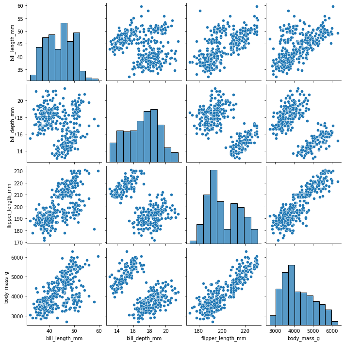

```python
sns.pairplot(data)
```

In most of the graphs there are two clusters visible, but in body_mass & bill_length are no clusters distinguishable. In bill_depth & bill_length there are even three clouds visible, though they are close together.

### KMeans

```python
features = ['body_mass_g', 'flipper_length_mm', 'bill_depth_mm', 'bill_length_mm']
km = KMeans(n_clusters = 2, random_state = 42).fit(data[features])
```

```python
data['cluster'] = km.predict(data[features])
```

```python
data.cluster.value_counts()
```

```
1    203
0    130
Name: cluster, dtype: int64
```

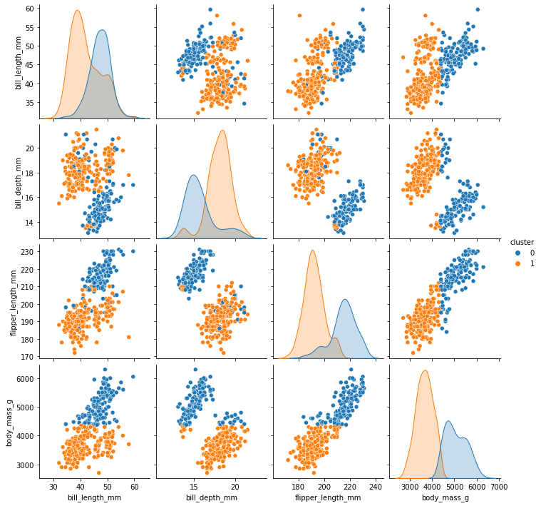

```python
sns.pairplot(data, hue='cluster')
```

### Silhouette Coefficient

```python
metrics.silhouette_score(data[features], km.labels_, metric = 'euclidean')
```

```
0.6307117469850305
```

This score of 0.63 means we have distinguishable clusters, not very impressive but not very bad either

### Best Silhouette Coefficient

```python
metrics.silhouette_score(data[['body_mass_g', 'bill_depth_mm']], km.labels_, metric = 'euclidean')
```

```
0.6310839036540167
```

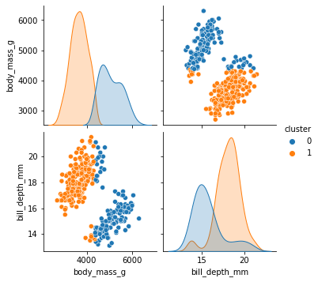

```python
sns.pairplot(data[['body_mass_g', 'bill_depth_mm', 'cluster']], hue='cluster')
```

### Contingencytable

```python
contingency_table = data.groupby(['species','cluster']).size().unstack('cluster', fill_value=0)
contingency_table
```

| cluster species | 0 | 1 |
| --- | --- | --- |
| Adelie | 14 | 132 |
| Chinstrap | 5 | 63 |
| Gentoo | 111 | 8 |

This table shows the clusters are not really good. The features with the highest Silhouette Coefficient are not quite correctly clustered, from every species there are a few penguins placed in the wrong cluster.